# Limitations and Bugs on the platform

```python
from IPython.display import *
import IPython.core.display as di # Example: di.display_html('<h3>%s:</h3>' % str, raw=True)
# This line will hide code by default when the notebook is exported as HTML
di.display_html('<script>jQuery(function() {if (jQuery("body.notebook_app").length == 0) { jQuery(".input_area").toggle(); jQuery(".prompt").toggle();}});</script>', raw=True)

# This line will add a button to toggle visibility of code blocks, for use with the HTML export version
di.display_html('''<button onclick="jQuery('.input_area').toggle(); jQuery('.prompt').toggle();">Toggle code</button>''', raw=True)
```

## 1. General

**For setting up the general properties on the platform:**

- The cell size can not be defined when a new model is created

[figure not shown]

```python
Image('pic/createmodel.png')
```

- The units are fixed and can not be changed

[figure not shown]

```python
Image('pic/units.png')
```

**For uploading a shape file to define the model area:**

- the mesh girds are always horizontal, which means the girds would not rotate when the projection is different from EPSG:3857 (The projection for Open Street Map). Rotation could be added in this part.

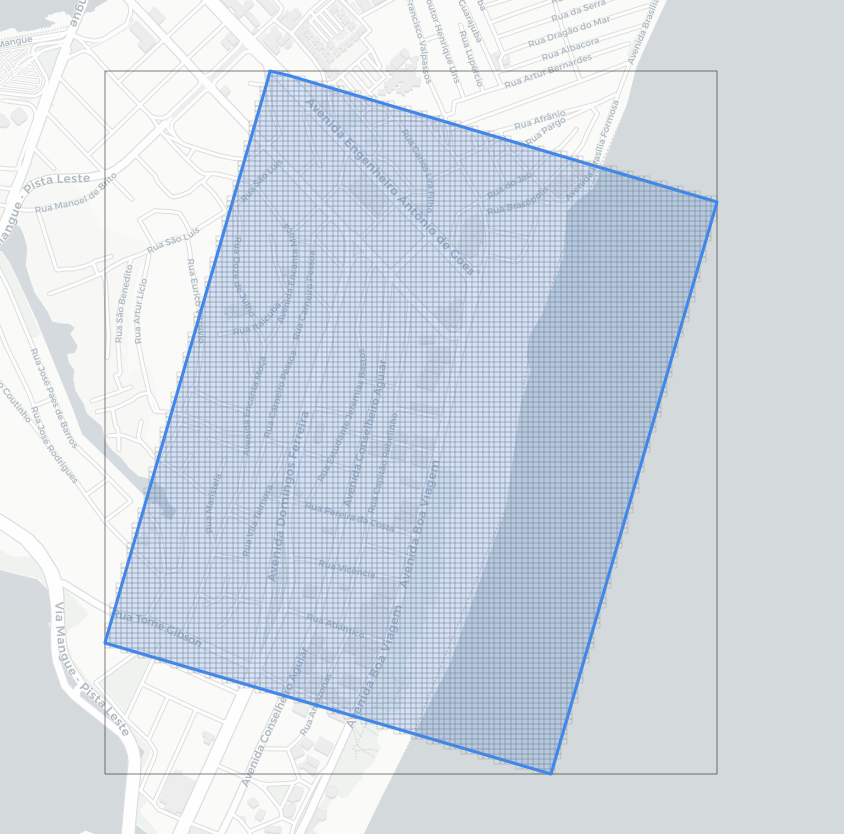

```python
Image('pic/grid.png')
```

**There is no option to define 'starting heads' and 'ibound' for models on the platform:**

- For starting heads, it has been defined as the same value as the top elevation.
- For ibound, all the cells are assumed to be active. However, sometimes constant boundary is not always equal to Time Variant Boundary (E.g. Using constant boundary to present seawater)

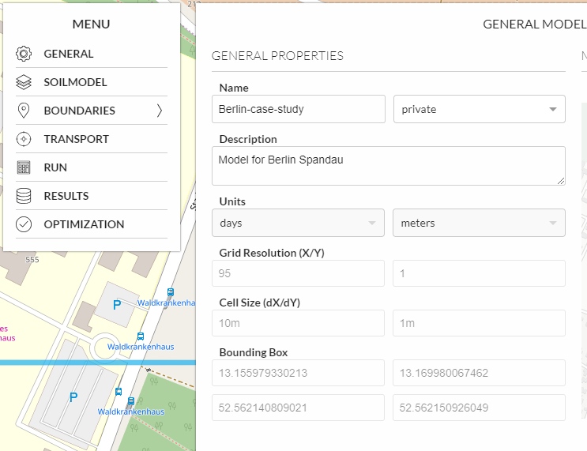

```python
Image('pic/ibound.png')
```

## 2. Soil model

### 2.1 Elevation

For setting up the elevation, it can be done by three ways:

- Set a single value for the whole layer
- Import a raster file
- Add a new zone and define the values the zone area

However

*1. For 'set a single value', the negative value does not work on the platform*

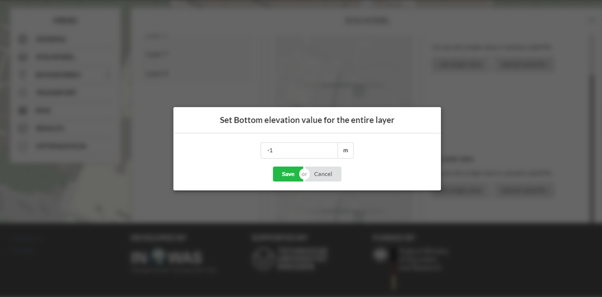

```python
Image('pic/elevationerror.png')
```

*2. For importing a raster file, if the values in the raster file is negative, the results will be null*

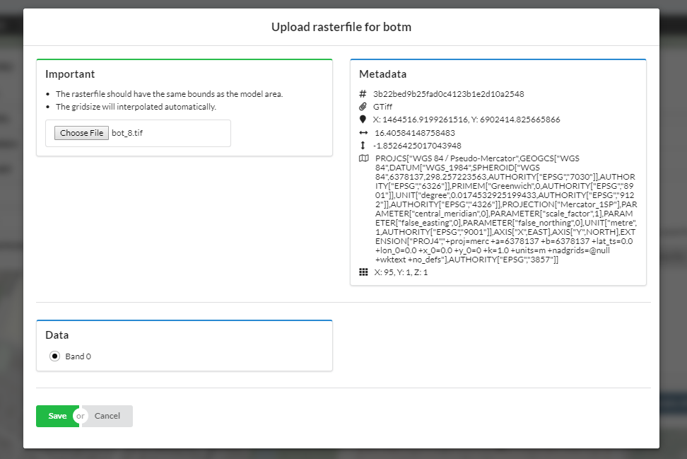

```python
Image('pic/rastererror.png')
```

*3. For adding a new zone, the details of selected cells (row/column numbers) can not be seen.*

[figure not shown]

```python
Image('pic/newzone.png')
```

*For the other features (hk, ss...), they have the same problems as 'elevation'.*

### * For models with multiple layers, the order of the layers changes when the user refreshes the page.

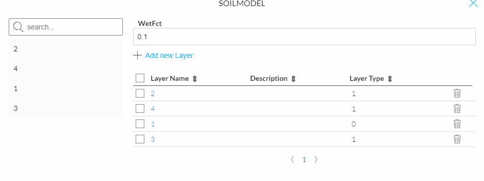

```python
Image('pic/layer_number.png')
```

## 3. Boundaries

For Boundaries, there are three types: area (e.g. Recharge), line(e.g. CHD, GHB) and point (e.g. well).

### 3.1 Area (Recharge)

To define a zone (or area) of recharge, it can be done by drawing on the map.

[figure not shown]

```python
Image('pic/boundary_area.png')
```

*However, the total number of affected cells are not shown on the map. It could be useful for the user to see the number of affected cells.*

### 3.2 Line (CHD)

*Same problem as the one above.*

[figure not shown]

```python
Image('pic/Boundary_line.png')
```

### 3.3 Point (Well)

*For point boundaries, the amount of affected cells are not necessary. However, the significant is the location of the point. However, on the map, no information about the number of the row or column is presented.*

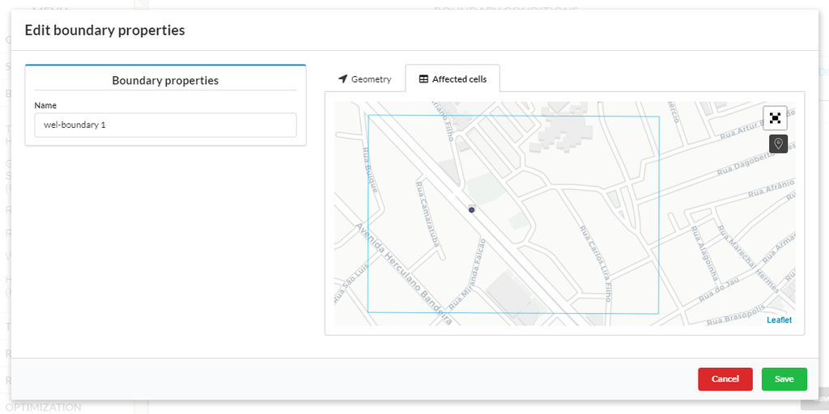

```python
Image('pic/Boundary_point.png')
```

## 4. Transport

*The Chemical Reaction Package is missing*

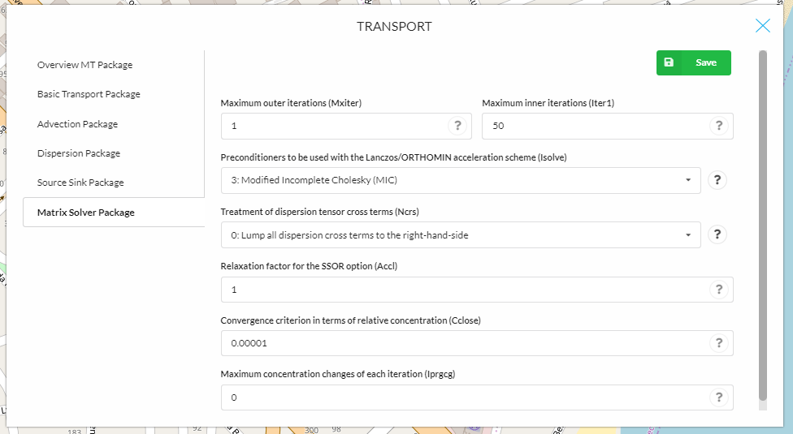

```python
Image('pic/transport.png')
```

## 5. Run

The key parameter in the 'RUN' part is 'Time discretization'

[figure not shown]

```python
Image('pic/time.png')
```

*However, it could be better if the number of days are shown in the grey rectangular. And the parameter in the red rectangular only depends on the stress period of the boundary.*

## 6. Results

### 6.1 Head results

*It could be better if row and column numbers are displayed on the map.*

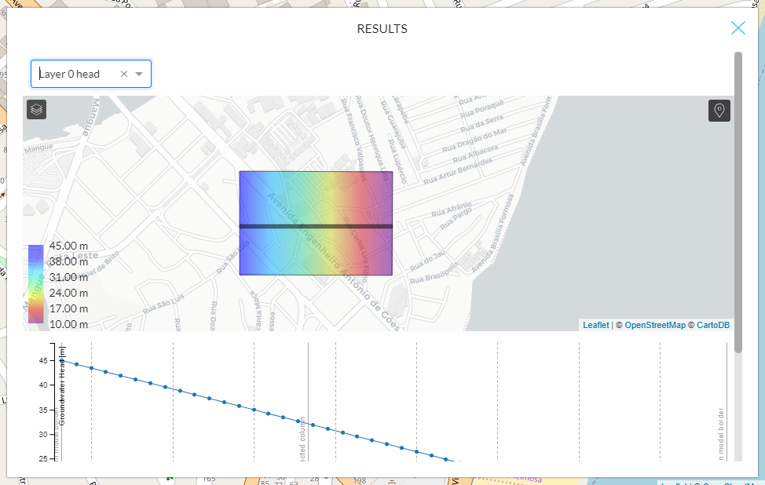

```python
Image('pic/head.png')
```

### 6.2 Transport results

*The unit of concentration should not be 'm'.*

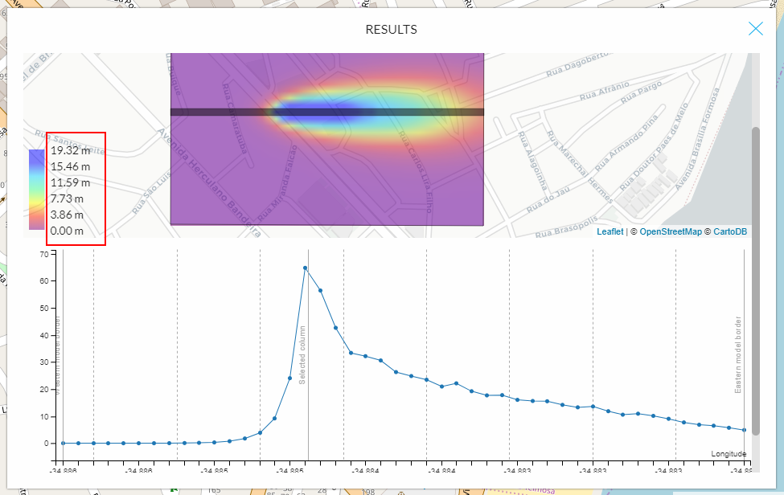

```python
Image('pic/concentration.png')
```